# Handbook of Broadleaf.Korean.pine.LAI

## 软件包简介

叶面积指数（LAI）指单位水平地面面积上总叶面积的一半，为植物冠层结构的最常用参数之一。我团队提出了一种基于分层泰森多边形估算复层林叶面积指数的方法，相较于传统基于公式的叶面积指数估计方法，该法可通过泰森多边形估算林分中各林木的树冠下叶面积指数，并在此基础上较为准确的计算林分中任意位点处的若干与叶面积指数相关的冠层结构参数（局部叶面积指数、局部叶面积指数标注差、各类树种对局部叶面积指数的贡献率，叶面积指数垂直结构特征等）。

我团队将基于分层泰森多边形估算复层林叶面积指数的方法用于阔叶红松林叶面积指数的估算，开发了R包Broadleaf.Korean.pine.LAI。

## 依赖关系

本包依赖于 ape；sp ；sf；raster；grDevices；rgeos；gstat ；tcltk ；ggplot2；plot3D ；deldir ；grDevices；stats 运行前请先安装

## 软件包安装方式

library(devtools);install_github(“DuXinChina/Broadleaf.Korean.pine.LAI/Broadleaf.Korean.pine.LAI”)

## 1 示例数据展示

示例数据为虚拟数据，数据为50m×50m样地，样地中包含色木、紫椴、冷杉、红松四种树种的空间坐标、胸径、树高信息。依据树高，将阔叶红松林分为不同林层。其中，下木层树高小于10m；亚林层树高为10m—16m；主林层树高为16m—30m；超冠层树高大于30m。虚拟数据中，超冠层包含两株红松，为随机分布；主林层中包含15株红松、10株冷杉、10株紫椴、5株色木，均为随机分布；亚林层中包含50株色木，为以（10,40）和（40,10）为中心的各25株的聚集分布；林下层包含四类树种各20株植株，各树种在小尺度为聚集分布，在大尺度为随机分布。超冠层中，林木胸径大于60cm；主林层中，林木胸径为30cm—60 cm；亚林层中林木胸径为10 cm-30cm；下木层胸径小于10 cm。

数据中x与y列分别为林木横纵坐标、DBH为胸径、H为树高、Species列为树种种名。

Species列可包含的常见树种种名为HS 红松、YS 云杉、LS 冷杉、ZD 紫椴、KD 糠椴、MGL 蒙古栎、SQL 水曲柳、HTQ 胡桃楸、HBL 黄檗、SMQ 色木槭、QKQ 青楷槭。HKQ 花楷槭、JSQ 假色槭、NJQ 拧筋槭、BNQ 白牛槭、CY 春榆、BH 白桦、HH 怀槐、FH 枫桦、LYY 裂叶榆、QT 其他树种。

```r
data = Broadleaf.Korean.pine.LAI::b
data
```

```
##              x          y       DBH  H Species
## 1   33.4288480 18.9819806 65.580755 35      HS
## 2    6.4346078 42.0391756 66.180769 35      HS
## 3   18.1460637 19.2660497 52.264410 25      HS
## 4   27.5928278 13.8968076 32.366493 25      HS
## 5    6.1081642 25.6396705 35.555799 25      HS
## 6   39.5111778  5.1855691 53.037166 25      HS
## 7   18.2991147 36.4641006 31.796712 25      HS
## 8   25.6670756  4.6233300 31.566986 25      HS
## 9   25.2746910  5.0032010 34.373929 25      HS
## 10  11.1674790  8.0279473 58.859233 25      HS
## 11  10.9212414 11.5923407 35.492684 25      HS
## 12  22.6771733 12.8692340 50.351396 25      HS
## 13   3.1528245 40.5892981 40.749832 25      HS
## 14  48.9035375 10.3960484 43.531746 25      HS
```

[output cut: 156 more lines]

## 2 示例

### 2.1 LAI.single(a,b,r)

2.1.1功能介绍： 基于传统方法，计算阔叶红松林内以任意位点为中心，一定半径的圆形区域内的叶面积指数，并给出不同树种在叶面积指数中的占比，及针叶树种与阔叶树种叶面积指数的占比。

2.1.2参数意义： a—需要计算叶面积指数的位点坐标 b—样地中林木的坐标、树种、胸径、树高信息 r—以位点中心圆的半径

2.1.3例：

计算以（25,25）为中心5m为半径的圆内的叶面积

```r
a=matrix(c(25,25),1,2)
colnames(a)=c("x","y")
a
```

```
##       x  y
## [1,] 25 25
```

```r
b=Broadleaf.Korean.pine.LAI::b[,-4]
head(b)
```

```
##           x         y      DBH Species
## 1 33.428848 18.981981 65.58075      HS
## 2  6.434608 42.039176 66.18077      HS
## 3 18.146064 19.266050 52.26441      HS
## 4 27.592828 13.896808 32.36649      HS
## 5  6.108164 25.639671 35.55580      HS
## 6 39.511178  5.185569 53.03717      HS
```

```r
Broadleaf.Korean.pine.LAI::LAI.single(a=a,b=b,r=5)
```

```
## $LAI
## [1] 12.23283
##
## $Species_LAI
##      HS_LAI LS_LAI YS_LAI ZD_LAI KD_LAI MGL_LAI SQL_LAI HTQ_LAI HBL_LAI
## [1,]      0      0      0      0      0       0       0       0       0
##       SMQ_LAI QKQ_LAI HKQ_LAI JSQ_LAI NJQ_LAI BNQ_LAI CY_LAI BH_LAI HH_LAI
## [1,] 12.23283       0       0       0       0       0      0      0      0
##      FH_LAI LYY_LAI QT_LAI
## [1,]      0       0      0
##
## $N_B_LAI
##      Needles_LAI Broadleaf_LAI N_L_percent B_L_percent
## [1,]           0      12.23283           0         100
```

总叶面积指数为12.23283、树种色木槭叶面积为12.23283、阔叶树种叶面积12.23283、阔叶占比100%

### 2.2 LAI.mult(a,b,r)

2.2.1功能介绍： 计算阔叶红松林内的多个位点为中心，一定半径的圆形区域内的叶面积指数，针叶树种与阔叶树种叶面积指数以及针阔叶面积分别的占比。

2.2.2参数意义：

a—需要计算叶面积指数的多个位点坐标

b—样地中林木的坐标、树种、胸径、树高信息

r—以位点中心圆的半径

2.2.3例：

计算多个样点的叶面积指数，针叶叶面积指数，阔叶叶面积指数以及针阔叶树种叶面积指数的占比

```r
a=matrix(runif(10,5,45),5,2)
colnames(a)=c("x","y")
a=as.data.frame(a)
a
```

```
##           x         y
## 1 22.620917 23.239634
## 2 10.191897  9.485000
## 3 11.337259  6.751937
## 4  9.478818 34.610415
## 5 40.675446 40.486808
```

```r
b=Broadleaf.Korean.pine.LAI::b[,-4]
head(b)
```

```
##           x         y      DBH Species
## 1 33.428848 18.981981 65.58075      HS
## 2  6.434608 42.039176 66.18077      HS
## 3 18.146064 19.266050 52.26441      HS
## 4 27.592828 13.896808 32.36649      HS
## 5  6.108164 25.639671 35.55580      HS
## 6 39.511178  5.185569 53.03717      HS
```

```r
Broadleaf.Korean.pine.LAI::LAI.mult(a=a,b=b,r=5)
```

```
## $LAI
##           x         y        LAI
## 1 22.620917 23.239634  0.6615122
## 2 10.191897  9.485000 18.1454956
## 3 11.337259  6.751937 12.4831165
## 4  9.478818 34.610415 13.6670219
## 5 40.675446 40.486808  0.3555538
##
## $B_N_LAI
##           x         y Needles_LAI Broadleaf_LAI N_L_percent B_L_percent
## 1 22.620917 23.239634   0.0000000     0.6615122     0.00000  100.000000
## 2 10.191897  9.485000  17.9309321     0.2145634    98.81754    1.182461
## 3 11.337259  6.751937  12.4831165     0.0000000   100.00000    0.000000
## 4  9.478818 34.610415   0.0000000    13.6670219     0.00000  100.000000
## 5 40.675446 40.486808   0.1618193     0.1937345    45.51191   54.488093
```

### 2.3 Plot.LAI.Krig (minx,maxx,miny,maxy,b,seq,r)

2.3.1功能介绍： 绘制阔叶红松林叶面积指数的克里格插值图。计算阔叶红松林叶面积指数半变异函数

2.3.2参数意义：

minx—绘制克里格插值图的最小横坐标

maxx—绘制克里格插值图的最大横坐标

miny—绘制克里格插值图的最小纵坐标

maxy—绘制克里格插值图的最大纵坐标

b—样地中的林木坐标、树种、胸径

seq—绘制克里格图的空间分辨率

r—以位点中心圆的半径

2.3.3例：

####

```r
b=Broadleaf.Korean.pine.LAI::b[,-4]
head(b)
```

```
##           x         y      DBH Species
## 1 33.428848 18.981981 65.58075      HS
## 2  6.434608 42.039176 66.18077      HS
## 3 18.146064 19.266050 52.26441      HS
## 4 27.592828 13.896808 32.36649      HS
## 5  6.108164 25.639671 35.55580      HS
## 6 39.511178  5.185569 53.03717      HS
```

```r
head(b)
```

```
##           x         y      DBH Species
## 1 33.428848 18.981981 65.58075      HS
## 2  6.434608 42.039176 66.18077      HS
## 3 18.146064 19.266050 52.26441      HS
## 4 27.592828 13.896808 32.36649      HS
## 5  6.108164 25.639671 35.55580      HS
## 6 39.511178  5.185569 53.03717      HS
```

```
##   model     psill    range
## 1   Nug   1.77716 0.000000
## 2   Sph 118.41951 6.636184
```

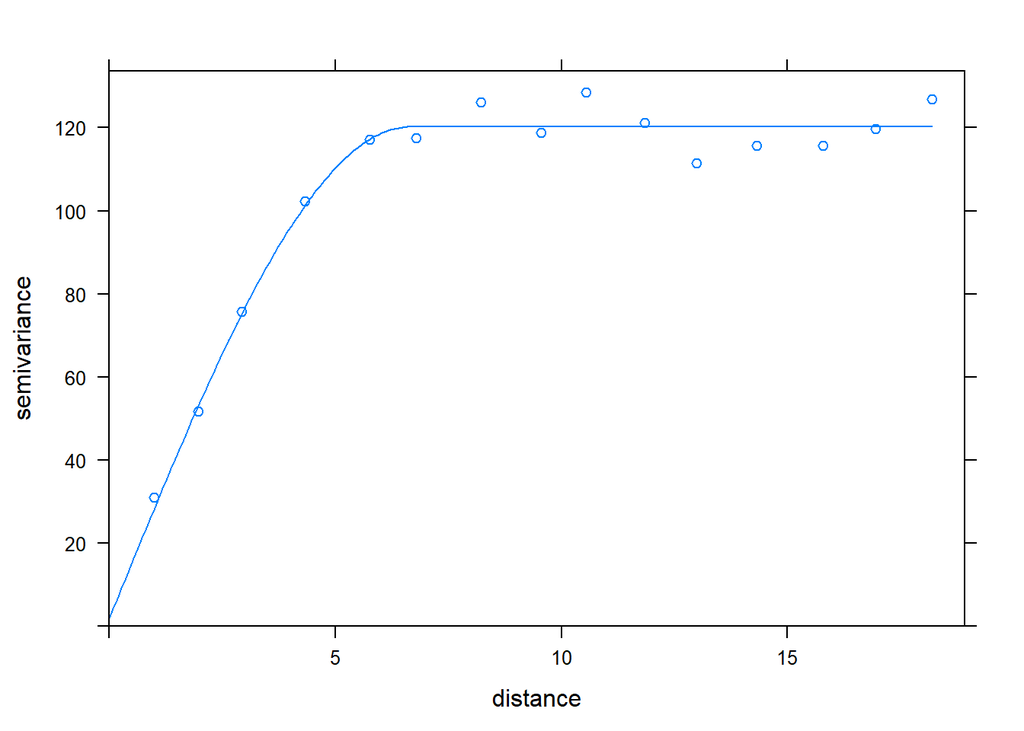

```
## [1] "Coefficient_of_Determination= 0.976014299370735"
## [using ordinary kriging]
```

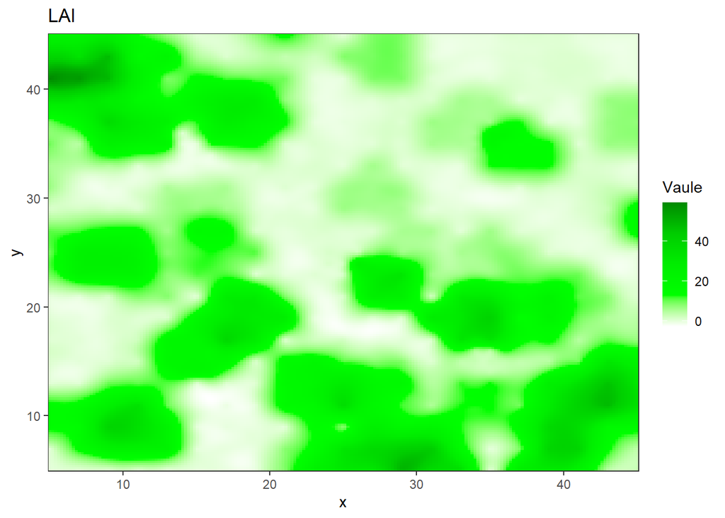

```r
p=Broadleaf.Korean.pine.LAI::Plot.LAI.Krig(5,45,5,45,b=b,seq=20,r=3)
```

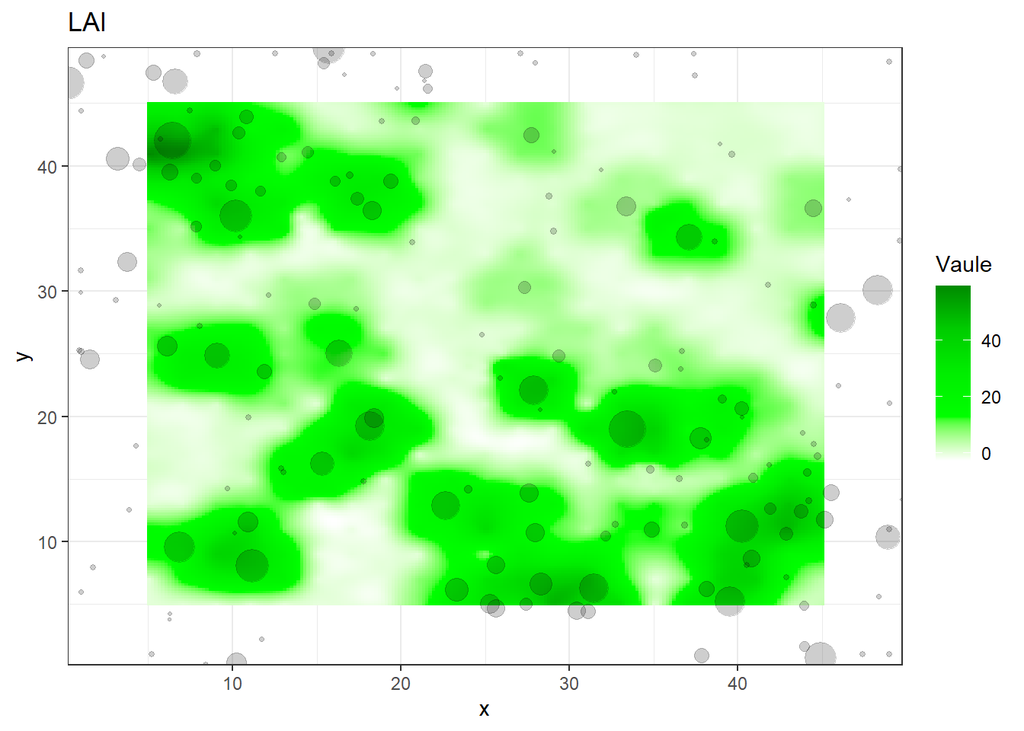

```r
p1=p+geom_vline(xintercept = c(5,45),linetype=2)+geom_hline(yintercept =c(5,45),linetype=2)
p1=p+scale_x_continuous(expand= c(0, 5))+scale_y_continuous(expand= c(0, 5))
p2=p1+geom_point(data=b,aes(x=x,y=y),size=b$DBH/8,col="grey4",alpha=0.2)+scale_x_continuous(expand= c(0, 0))+scale_y_continuous(expand= c(0, 0))
p2
```

### **2.4 Standing_Forest_LAI(minx,maxx,miny,maxy,b)**

2.4.1功能介绍：

计算阔叶红松林全林分的叶面积指数，并给出不同树种叶面积指数的量与占比，以及针、阔叶树种叶面积指数的量与占比。

2.4.2 参数意义：

minx—计算叶面积指数样地横坐标最小边界

maxx—计算叶面积指数样地横坐标最大边界

miny—计算叶面积指数样地纵坐标最小边界

maxy—计算叶面积指数样地纵坐标最大边界

b—林木分布信息

2.4.3例：

```r
b=Broadleaf.Korean.pine.LAI::b[,-4]
head(b)
```

```
##           x         y      DBH Species
## 1 33.428848 18.981981 65.58075      HS
## 2  6.434608 42.039176 66.18077      HS
## 3 18.146064 19.266050 52.26441      HS
## 4 27.592828 13.896808 32.36649      HS
## 5  6.108164 25.639671 35.55580      HS
## 6 39.511178  5.185569 53.03717      HS
```

```r
Broadleaf.Korean.pine.LAI::Standing_Forest_LAI(minx=5,maxx=45,miny=5,maxy=45,b)
```

```
## $LAI
## [1] 11.25676
##
## $Species_LAI
##        HS_LAI   LS_LAI YS_LAI   ZD_LAI KD_LAI MGL_LAI SQL_LAI HTQ_LAI HBL_LAI
## [1,] 3.948259 1.242444      0 1.352644      0       0       0       0       0
##       SMQ_LAI QKQ_LAI HKQ_LAI JSQ_LAI NJQ_LAI BNQ_LAI CY_LAI BH_LAI HH_LAI
## [1,] 4.713409       0       0       0       0       0      0      0      0
##      FH_LAI LYY_LAI QT_LAI
## [1,]      0       0      0
##
## $N_B_LAI
##      Needles_LAI Broadleaf_LAI N_L_percent B_L_percent
## [1,]    5.190703      6.066053    46.11189    53.88811
```

### **2.5 LSD_LAI(a,b,r,Lr)**

2.5.1功能介绍：

在以一定半径圆的面积为分辨率计算阔叶红松林叶面指数后。计算以某一位点为中心，一定半径圆内叶面积指数的局部标准差。通常情况下，林缘处及大树小树的冠层交错处的叶面积指数具有较大的局部标准差。

2.5.2参数意义：

a—需要计算叶面积指数局部标准差的位点坐标

b—林木分布信息及胸径、树高

r—计算林木内叶面积指数时所用圆的半径

Lr—计算位点叶面积指数局部标准差时所用圆的半径

2.5.3例：

```r
a=data.frame(28,25)
colnames(a)=c("x","y")
a
```

```
##    x  y
## 1 28 25
```

```r
b=Broadleaf.Korean.pine.LAI::b[,-4]
head(b)
```

```
##           x         y      DBH Species
## 1 33.428848 18.981981 65.58075      HS
## 2  6.434608 42.039176 66.18077      HS
## 3 18.146064 19.266050 52.26441      HS
## 4 27.592828 13.896808 32.36649      HS
## 5  6.108164 25.639671 35.55580      HS
## 6 39.511178  5.185569 53.03717      HS
```

```r
result=Broadleaf.Korean.pine.LAI::LSD_LAI(a=a,b=b,r=3,Lr=1.5)
result
```

```
##    x  y  LSD_LAI
## 1 28 25 13.82343
```

### **2.6 LSD_LAI_mult(a,b,r,Lr)**

2.6.1功能介绍：

计算多个位点叶面积指数的局部标准差

2.6.2参数意义：

a—需要计算叶面积指数局部标准差的位点坐标

b—林木分布信息及胸径、树高

r—计算林木内叶面积指数时所用圆的半径

Lr—计算位点叶面积指数局部标准差时所用圆的半径

2.6.3例：

```r
a=matrix(runif(10,5,45),5,2)
colnames(a)=c("x","y")
a=as.data.frame(a)
a
```

```
##           x        y
## 1 11.910299 33.28216
## 2 38.291663 14.58496
## 3 17.615739 33.31745
## 4  7.594751 24.31607
## 5 14.801852 19.40255
```

```r
b=Broadleaf.Korean.pine.LAI::b[,-4]
head(b)
```

```
##           x         y      DBH Species
## 1 33.428848 18.981981 65.58075      HS
## 2  6.434608 42.039176 66.18077      HS
## 3 18.146064 19.266050 52.26441      HS
## 4 27.592828 13.896808 32.36649      HS
## 5  6.108164 25.639671 35.55580      HS
## 6 39.511178  5.185569 53.03717      HS
```

```r
result=Broadleaf.Korean.pine.LAI::LSD_LAI_mult(a=a,b=b,r=3,Lr=1.5)
formattable::formattable(result)
```

| x | y | LSD_LAI |
| --- | --- | --- |
| 11.910299 | 33.28216 | 10.155311 |
| 38.291663 | 14.58496 | 7.173425 |
| 17.615739 | 33.31745 | 4.786455 |
| 7.594751 | 24.31607 | 5.277411 |
| 14.801852 | 19.40255 | 14.379131 |

### **2.7 Plot.LSD_LAI.Krig(minx,maxx,miny,maxy,b,seq,r,Lr)**

2.7.1功能介绍：

绘制阔叶红松林叶面积指数局部标准差的克里格插值图。计算阔叶红松林叶面积指数局部标准差的半变异函数。

2.7.2参数意义：

minx—绘制克里格插值图的最小横坐标

maxx—绘制克里格插值图的最大横坐标

miny—绘制克里格插值图的最小纵坐标

maxy—绘制克里格插值图的最大纵坐标

b—样地中的林木坐标、树种、胸径

seq—绘制克里格图的空间分辨率

r—计算林分叶面积指数时以位点中心圆的半径

Lr—计算林分叶面积指数局部标准差时取样圆的半径

2.7.3例：

```
##   model    psill    range
## 1   Nug 4.822950 0.000000
## 2   Sph 9.399724 3.202621
```

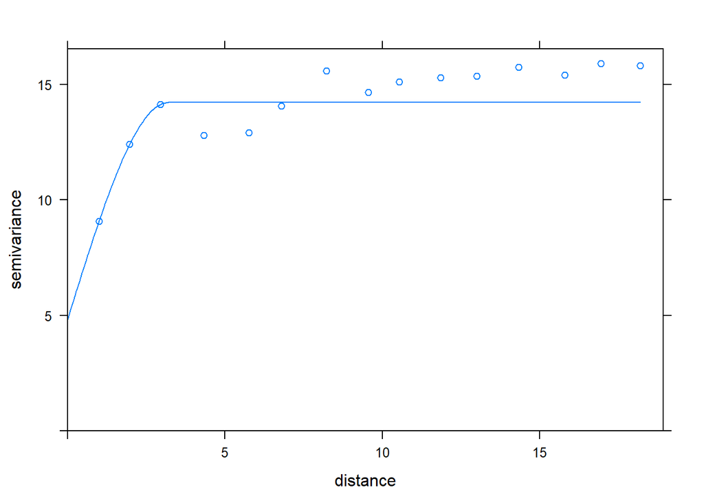

```
## [1] "Coefficient_of_Determination= 0.620507794377322"
## [using ordinary kriging]
```

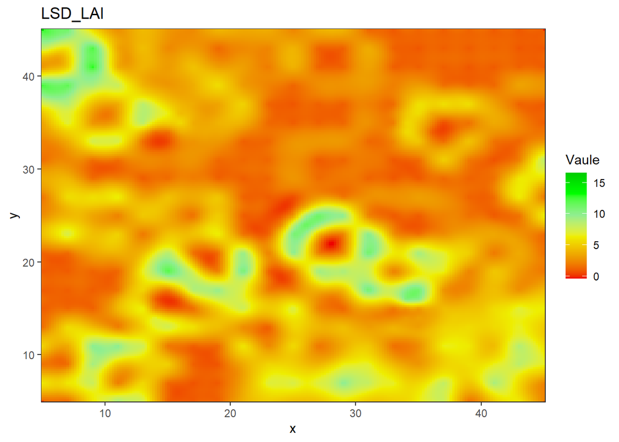

```r
p=Broadleaf.Korean.pine.LAI::Plot.LSD_LAI.Krig(minx=5,maxx=45,miny=5,maxy=45,b=b,seq=20,r=3,Lr=1)
```

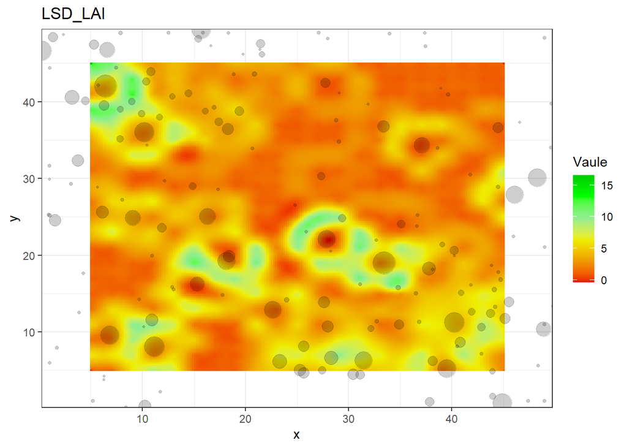

```r
p1=p+geom_vline(xintercept = c(5,45),linetype=2)+geom_hline(yintercept =c(5,45),linetype=2)
p1=p+scale_x_continuous(expand= c(0, 5))+scale_y_continuous(expand= c(0, 5))
p2=p1+geom_point(data=b,aes(x=x,y=y),size=b$DBH/8,col="grey4",alpha=0.2)+scale_x_continuous(expand= c(0, 0))+scale_y_continuous(expand= c(0, 0))
p2
```

### **2.8 Voronoi.LAI(minx,maxx,miny,maxy,boundary,b,r)**

2.8.1功能介绍：

基于泰森多边形法计算林地内（单一林层）各株树木下的叶面积指数。

2.8.2参数意义：

minx—样地横坐标最小范围

maxx—样地横坐标最大范围

miny—样地纵坐标最小范围

maxy—样地纵坐标最大范围

boundary—样地边界缓冲区宽度

b—样地中的林木坐标、树种、胸径

r—将在林分中没有林木分布的位置添加样点，以避免以林木为中心的泰森多边形过大。r为添加样点构成泰森多边形外接圆的半径

2.8.3例：

```r
b=Broadleaf.Korean.pine.LAI::b
b=subset(b,b$H<10)
b=b[,-4]
head(b)
```

```
##           x        y      DBH Species
## 93 39.64364 40.98114 9.934820      LS
## 94 49.61224 34.02107 8.551500      LS
## 95 46.58680 37.33223 5.193316      LS
## 96 49.00000 48.30858 8.632041      LS
## 97 29.08525 41.11792 6.165639      LS
## 98 29.02066 34.80735 9.694307      LS
```

```r
result=Broadleaf.Korean.pine.LAI::Voronoi.LAI(minx=0,maxx=50,miny=0,maxy=50,boundary=5,b=b,r=2)
```

```
## deldir 0.1-25
```

[output not shown]

```r
formattable::formattable(result)
```

|  | x | y | DBH | Species | deldir_area | LAI |
| --- | --- | --- | --- | --- | --- | --- |
| 1131 | 49.0000000 | 1.0000000 | 9.106646 | HS | 6.351193 | 3.5706003 |
| 1141 | 48.3429683 | 5.6185863 | 7.605254 | HS | 10.526040 | 1.5490501 |
| 1151 | 40.5465709 | 8.1345473 | 8.666798 | HS | 8.673114 | 2.3881160 |
| 1161 | 49.0000000 | 11.0004526 | 9.061282 | HS | 9.023746 | 2.4902250 |
| 1171 | 6.2794533 | 4.2384272 | 5.919919 | HS | 6.923454 | 1.4886705 |
| 1181 | 1.0000000 | 5.9588289 | 7.419849 | HS | 11.101522 | 1.4038545 |
| 1191 | 3.8418102 | 12.5395119 | 6.657954 | HS | 9.804799 | 1.3034956 |
| 1201 | 1.7257937 | 7.9206185 | 8.538493 | HS | 9.751063 | 2.0668947 |
| 1211 | 41.8513062 | 16.1607322 | 7.772832 | HS | 10.233926 | 1.6581341 |
| 1221 | 40.2428301 | 19.8903321 | 5.406923 | HS | 10.203823 | 0.8556186 |
| 1231 | 36.5047511 | 15.0316257 | 9.628256 | HS | 9.955278 | 2.5225137 |
| 1241 | 36.7982127 | 11.3218356 | 9.553490 | HS | 11.079585 | 2.2344182 |
| 1251 | 31.1297617 | 16.2011382 | 8.440440 | HS | 9.774625 | 2.0187643 |
| 1261 | 36.6997820 | 25.2196392 | 7.903824 | HS | 8.563030 | 2.0432608 |
| 1271 | 32.7186422 | 11.4235729 | 9.530176 | HS | 11.262486 | 2.1883197 |
| 1281 | 28.2869781 | 20.5159761 | 6.201615 | HS | 9.819162 | 1.1429130 |
| 1291 | 17.7794649 | 14.8297948 | 8.094559 | HS | 10.289700 | 1.7762754 |
| 1301 | 13.0119315 | 15.5301695 | 8.087604 | HS | 8.745888 | 2.0865342 |
| 1311 | 12.8823991 | 15.8329528 | 8.933832 | HS | 6.865428 | 3.1892889 |
| 1321 | 10.1283477 | 10.6649023 | 5.769270 | HS | 10.686881 | 0.9199679 |
| 931 | 39.6436424 | 40.9811422 | 9.934820 | LS | 6.717356 | 1.8920034 |
| 941 | 49.6122418 | 34.0210738 | 8.551500 | LS | 10.466771 | 0.8900805 |
| 951 | 46.5867969 | 37.3322312 | 5.193316 | LS | 9.450425 | 0.3508748 |
| 961 | 49.0000000 | 48.3085792 | 8.632041 | LS | 9.759273 | 0.9733234 |
| 971 | 29.0852543 | 41.1179223 | 6.165639 | LS | 10.572632 | 0.4475085 |
| 981 | 29.0206565 | 34.8073513 | 9.694307 | LS | 9.591146 | 1.2595182 |
| 991 | 28.7770563 | 37.6178602 | 9.306080 | LS | 10.123716 | 1.0964011 |
| 1001 | 38.6189406 | 33.9430026 | 8.822112 | LS | 11.587956 | 0.8575519 |
| 1011 | 45.9365553 | 22.4422532 | 6.603459 | LS | 12.710238 | 0.4290834 |
| 1021 | 36.6124557 | 23.8282281 | 6.482322 | LS | 8.639266 | 0.6075241 |
| 1031 | 42.8625806 | 7.1329634 | 8.337840 | LS | 10.265588 | 0.8611864 |
| 1041 | 32.6357700 | 21.9731506 | 7.542603 | LS | 10.991263 | 0.6535290 |
| 1051 | 11.7305549 | 2.2269401 | 6.781676 | LS | 9.651604 | 0.5971063 |
| 1061 | 5.1875622 | 1.0000000 | 8.702628 | LS | 7.232443 | 1.3357205 |
| 1071 | 8.4335608 | 0.1246017 | 9.224902 | LS | 10.791388 | 1.0100682 |
| 1081 | 6.2689242 | 3.7764784 | 5.028092 | LS | 6.016010 | 0.5154787 |
| 1091 | 49.7399440 | 13.3581418 | 5.351386 | LS | 10.095259 | 0.3495082 |
| 1101 | 44.1681187 | 13.2980574 | 9.975786 | LS | 10.572373 | 1.2124097 |
| 1111 | 49.0000000 | 21.0523839 | 7.792711 | LS | 10.145719 | 0.7574857 |
| 1121 | 47.4105839 | 1.0000000 | 8.252535 | LS | 7.036175 | 1.2299673 |
| 1331 | 3.0805107 | 29.2901996 | 8.609461 | ZD | 7.397749 | 3.4315899 |
| 1341 | 0.9071648 | 25.2446763 | 8.010450 | ZD | 7.861971 | 2.8704561 |
| 1351 | 1.0000000 | 29.8599316 | 5.312565 | ZD | 7.944869 | 1.4531956 |
| 1361 | 1.0000000 | 31.6702470 | 8.310919 | ZD | 8.341543 | 2.8729964 |
| 1371 | 18.3311714 | 49.0000000 | 7.540457 | ZD | 7.238526 | 2.8247306 |
| 1381 | 21.4111116 | 46.7843710 | 5.504480 | ZD | 9.344123 | 1.3092564 |
| 1391 | 18.8694693 | 43.5405025 | 8.373520 | ZD | 8.301285 | 2.9225026 |
| 1401 | 19.7880615 | 46.1762995 | 5.829197 | ZD | 7.549090 | 1.7794798 |
| 1411 | 7.4560338 | 44.4200915 | 8.199286 | ZD | 8.359500 | 2.8042480 |
| 1421 | 16.6670340 | 47.2940320 | 6.212923 | ZD | 8.655479 | 1.7221941 |
| 1431 | 12.5297550 | 49.0000000 | 8.027718 | ZD | 9.927875 | 2.2811416 |
| 1441 | 15.8983970 | 49.0000000 | 7.926028 | ZD | 9.152429 | 2.4234644 |
| 1451 | 38.9231748 | 41.7665160 | 6.291640 | ZD | 5.676560 | 2.6804741 |
| 1461 | 37.4657599 | 47.2459319 | 8.682012 | ZD | 7.404217 | 3.4758700 |
| 1471 | 49.6668905 | 39.7330850 | 8.203196 | ZD | 11.848520 | 1.9800244 |
| 1481 | 31.8817342 | 39.6527677 | 5.795613 | ZD | 9.619317 | 1.3834013 |
| 1491 | 5.6448613 | 28.8535785 | 5.703050 | ZD | 9.278930 | 1.3969576 |
| 1501 | 4.2739190 | 17.6424662 | 6.565414 | ZD | 11.075167 | 1.4727726 |
| 1511 | 10.9522913 | 19.9384604 | 9.095775 | ZD | 11.712855 | 2.3707069 |
| 1521 | 9.6877684 | 14.2428889 | 6.697895 | ZD | 11.577869 | 1.4555159 |
| 1531 | 7.8820318 | 49.0000000 | 9.916860 | SMQ | 9.756934 | 4.7011145 |
| 1541 | 1.0000000 | 44.4448761 | 6.899585 | SMQ | 9.666726 | 2.5786428 |
| 1551 | 2.3695873 | 48.7241619 | 6.060310 | SMQ | 10.536778 | 1.9022829 |
| 1561 | 5.6845312 | 42.1728318 | 7.417518 | SMQ | 11.126609 | 2.5301780 |
| 1571 | 20.6701393 | 33.8747094 | 8.585438 | SMQ | 9.558668 | 3.7658803 |
| 1581 | 17.3413093 | 28.6130006 | 7.200311 | SMQ | 9.952959 | 2.6906948 |
| 1591 | 24.7963305 | 26.5485412 | 6.546525 | SMQ | 10.111355 | 2.2569088 |
| 1601 | 25.8814922 | 23.0839561 | 7.570419 | SMQ | 10.975876 | 2.6544254 |
| 1611 | 38.1404212 | 18.1701050 | 7.064143 | SMQ | 8.354546 | 3.1042401 |
| 1621 | 44.4997075 | 17.7732229 | 8.575503 | SMQ | 11.831227 | 3.0366083 |
| 1631 | 41.8010491 | 30.4660159 | 8.362883 | SMQ | 9.328978 | 3.6919476 |
| 1641 | 43.8052430 | 18.7144681 | 7.256104 | SMQ | 9.298452 | 2.9177030 |
| 1651 | 27.9742202 | 48.2190508 | 7.243758 | SMQ | 8.766556 | 3.0858836 |
| 1661 | 27.1037613 | 49.0000000 | 8.991668 | SMQ | 7.925497 | 4.9089445 |
| 1671 | 33.9898945 | 48.8409792 | 8.534445 | SMQ | 11.451778 | 3.1120164 |
| 1681 | 37.3406029 | 49.0000000 | 6.711967 | SMQ | 9.818730 | 2.4237531 |
| 1691 | 10.4386867 | 34.3300143 | 5.309605 | SMQ | 9.887581 | 1.6231128 |
| 1701 | 8.0524403 | 27.1832789 | 9.161863 | SMQ | 8.734993 | 4.5966489 |
| 1711 | 1.0000000 | 25.2146483 | 9.680147 | SMQ | 2.613125 | 16.8545260 |
| 1721 | 12.1497107 | 29.6801073 | 6.772546 | SMQ | 10.718650 | 2.2540481 |

### **2.9 Plot.Voronoi.LAI(minx,maxx,miny,maxy,boundary,b,r)**

2.9.1功能介绍：

基于泰森多边形法计算单层林或复层林内单一林层的林地内各位置的叶面积指数，并绘图。

2.9.2参数意义：

minx—样地横坐标最小范围

maxx—样地横坐标最大范围

miny—样地纵坐标最小范围

maxy—样地纵坐标最大范围

boundary—样地边界缓冲区宽度

b—样地中的林木坐标、树种、胸径

r—将在林分中没有林木分布的位置添加样点，以避免以林木为中心的泰森多边形过大。r为添加样点构成泰森多边形外接圆的半径

2.9.3例：

```r
b=Broadleaf.Korean.pine.LAI::b
b=subset(b,b$H>20 & b$H<30)
b=b[,-4]
head(b)
```

```
##           x         y      DBH Species
## 3 18.146064 19.266050 52.26441      HS
## 4 27.592828 13.896808 32.36649      HS
## 5  6.108164 25.639671 35.55580      HS
## 6 39.511178  5.185569 53.03717      HS
## 7 18.299115 36.464101 31.79671      HS
## 8 25.667076  4.623330 31.56699      HS
```

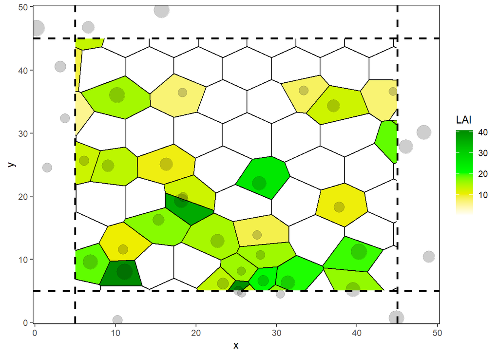

```r
p=Broadleaf.Korean.pine.LAI::Plot.Voronoi.LAI(minx=0,maxx=50,miny=0,maxy=50,boundary=5,b=b,r=3.5)
p1=p+geom_point(data=b,aes(x=x,y=y),size=b$DBH/8,col="grey4",alpha=0.2)
p1
```

### 2.10 Single.point.Voronoi.LAI(minx,maxx,miny,maxy,boundary,a,b,r)

2.10.1功能介绍：

基于泰森多边形法计算单层林或复层林内单一林层的林地内任意单一位点的叶面积指数。

2.10.2参数意义：

minx—样地横坐标最小范围

maxx—样地横坐标最大范围

miny—样地纵坐标最小范围

maxy—样地纵坐标最大范围

boundary—样地边界缓冲区宽度

a—需要计算叶面积指数的位点的坐标

b—样地中的林木坐标、树种、胸径

r—将在林分中没有林木分布的位置添加样点，以避免以林木为中心的泰森多边形过大。r为添加样点构成泰森多边形外接圆的半径

2.10.3例：

```r
a=matrix(runif(2,5,45),1,2)
colnames(a)=c("x","y")
a=as.data.frame(a)
a
```

```
##          x        y
## 1 9.806964 40.51719
```

```r
b=Broadleaf.Korean.pine.LAI::b
b=subset(b,b$H>20 & b$H<30)
b=b[,-4]
head(b)
```

```
##           x         y      DBH Species
## 3 18.146064 19.266050 52.26441      HS
## 4 27.592828 13.896808 32.36649      HS
## 5  6.108164 25.639671 35.55580      HS
## 6 39.511178  5.185569 53.03717      HS
## 7 18.299115 36.464101 31.79671      HS
## 8 25.667076  4.623330 31.56699      HS
```

```r
result=Broadleaf.Korean.pine.LAI::Single.point.Voronoi.LAI(minx=0,maxx=50,miny=0,maxy=50,boundary=5,a=a,b=b,r=3.5)
formattable::formattable(result)
```

|  | pointx | treex | treey | Species | LAI |
| --- | --- | --- | --- | --- | --- |
| 29 | 9.806964 | 8.155445 | 40.25 | LX | 0 |

### 2.11 mult.point.Voronoi.LAI(minx,maxx,miny,maxy,boundary,a,b,r)

2.11.1功能介绍：

基于泰森多边形法计算单层林或复层林内单一林层的林地内任意多个位点的叶面积指数。

2.11.2参数意义：

minx—样地横坐标最小范围

maxx—样地横坐标最大范围

miny—样地纵坐标最小范围

maxy—样地纵坐标最大范围

boundary—样地边界缓冲区宽度

a—需要计算叶面积指数的位点坐标

b—样地中的林木坐标、树种、胸径

r—将在林分中没有林木分布的位置添加样点，以避免以林木为中心的泰森多边形过大。r为添加样点构成泰森多边形外接圆的半径

2.11.3例：

```r
set.seed(100)
a=matrix(runif(40,5,45),20,2)
colnames(a)=c("x","y")
a=as.data.frame(a)
head(a)
```

```
##           x        y
## 1 17.310644 26.43245
## 2 15.306900 33.43215
## 3 27.092897 26.53395
## 4  7.255326 34.95889
## 5 23.741971 21.80406
## 6 24.350829 11.85681
```

```r
b=Broadleaf.Korean.pine.LAI::b
b=subset(b,b$H>20 & b$H<30)
b=b[,-4]
head(b)
```

```
##           x         y      DBH Species
## 3 18.146064 19.266050 52.26441      HS
## 4 27.592828 13.896808 32.36649      HS
## 5  6.108164 25.639671 35.55580      HS
## 6 39.511178  5.185569 53.03717      HS
## 7 18.299115 36.464101 31.79671      HS
## 8 25.667076  4.623330 31.56699      HS
```

```r
result=Broadleaf.Korean.pine.LAI::mult.point.Voronoi.LAI(minx=0,maxx=50,miny=0,maxy=50,boundary=5,a=a,b=b,r=3.5)
formattable::formattable(result)
```

| pointx | pointy | treex | treey | Species | LAI |
| --- | --- | --- | --- | --- | --- |
| 17.310644 | 26.43245 | 16.31137 | 25.048535 | LS | 10.05055 |
| 15.306900 | 33.43215 | 14.21762 | 29.750000 | LX | 0.00000 |
| 27.092897 | 26.53395 | 26.34198 | 29.750000 | LX | 0.00000 |
| 7.255326 | 34.95889 | 10.18809 | 36.037507 | ZD | 15.39914 |
| 23.741971 | 21.80406 | 23.31089 | 24.500000 | LX | 0.00000 |
| 24.350829 | 11.85681 | 22.67717 | 12.869234 | HS | 15.18164 |
| 37.496105 | 35.81206 | 37.09486 | 34.353282 | ZD | 12.69569 |
| 19.812821 | 40.27814 | 20.27980 | 40.250000 | LX | 0.00000 |
| 26.862344 | 26.96387 | 26.34198 | 29.750000 | LX | 0.00000 |
| 11.810482 | 16.10895 | 15.33661 | 16.214938 | SMQ | 17.00122 |
| 29.999859 | 24.53224 | 27.86636 | 22.076860 | SMQ | 25.00448 |
| 40.286621 | 42.14020 | 38.46633 | 40.250000 | LX | 0.00000 |
| 16.214154 | 18.94768 | 18.14606 | 19.266050 | HS | 35.88500 |
| 20.939516 | 43.16631 | 20.27980 | 40.250000 | LX | 0.00000 |
| 35.502043 | 32.81097 | 37.09486 | 34.353282 | ZD | 12.69569 |
| 31.760868 | 40.57814 | 32.40416 | 40.250000 | LX | 0.00000 |
| 13.184486 | 12.21629 | 10.92124 | 11.592341 | HS | 10.21953 |
| 19.300994 | 30.17563 | 20.27980 | 29.750000 | LX | 0.00000 |
| 19.379005 | 44.58257 | 17.24871 | 45.500000 | LX | 0.00000 |
| 32.611621 | 10.21155 | 31.41985 | 6.278545 | ZD | 20.20589 |

### 2.12 Local.single.point.Voronoi.LAI(minx,maxx,miny,maxy,boundary,a,b,r,Lr)

2.12.1功能介绍：

基于泰森多边形法计算单层林或复层林内单一林层的林地内任意单一位点的与叶面积有关的局部冠层结构参数。

2.12.2参数意义：

minx—样地横坐标最小范围

maxx—样地横坐标最大范围

miny—样地纵坐标最小范围

maxy—样地纵坐标最大范围

boundary—样地边界缓冲区宽度

a—需要模拟局部冠层结构参数的位置坐标

b—样地中的林木坐标、树种、胸径

r—将在林分中没有林木分布的位置添加样点，以避免以林木为中心的泰森多边形过大。r为添加样点构成泰森多边形外接圆的半径

Lr—提取局部冠层结构参数时的圆的半径

2.12.3例：

```r
set.seed(100)
a=matrix(runif(2,5,45),1,2)
colnames(a)=c("x","y")
a=as.data.frame(a)
a
```

```
##          x       y
## 1 17.31064 15.3069
```

```r
b=Broadleaf.Korean.pine.LAI::b
b=subset(b,b$H>20 & b$H<30)
b=b[,-4]
head(b)
```

```
##           x         y      DBH Species
## 3 18.146064 19.266050 52.26441      HS
## 4 27.592828 13.896808 32.36649      HS
## 5  6.108164 25.639671 35.55580      HS
## 6 39.511178  5.185569 53.03717      HS
## 7 18.299115 36.464101 31.79671      HS
## 8 25.667076  4.623330 31.56699      HS
```

```r
result=Broadleaf.Korean.pine.LAI::Local.single.point.Voronoi.LAI(minx=0,maxx=50,miny=0,maxy=50,boundary=5,a=a,b=b,r=3.5,Lr=1.5)
formattable::formattable(result)
```

| x | y | LAI | Local_min_LAI | Local_max_LAI | Local_mean_LAI | Local_sd_LAI | Gap_percent | Canopy_percent | N_L_Percent | B_L_Percent |
| --- | --- | --- | --- | --- | --- | --- | --- | --- | --- | --- |
| 17.31064 | 15.3069 | 17.00122 | 17.00122 | 35.885 | 17.20648 | 1.961598 | 0 | 1 | 0.02266904 | 0.977331 |

### 2.13 Local.mult.point.Voronoi.LAI(minx,maxx,miny,maxy,boundary,a,b,r,Lr)

2.13.1功能介绍：

基于泰森多边形法计算单层林或复层林内单一林层的林地内任意多个位点的与叶面积有关的局部冠层结构参数。

2.13.2参数意义：

minx—样地横坐标最小范围

maxx—样地横坐标最大范围

miny—样地纵坐标最小范围

maxy—样地纵坐标最大范围

boundary—样地边界缓冲区宽度

a—需要模拟局部冠层结构参数的位置坐标

b—样地中的林木坐标、树种、胸径

r—将在林分中没有林木分布的位置添加样点，以避免以林木为中心的泰森多边形过大。r为添加样点构成泰森多边形外接圆的半径

Lr—提取局部冠层结构参数时的圆的半径

2.13.3例：

```r
set.seed(100)
a=matrix(runif(40,5,45),20,2)
colnames(a)=c("x","y")
a=as.data.frame(a)
head(a)
```

```
##           x        y
## 1 17.310644 26.43245
## 2 15.306900 33.43215
## 3 27.092897 26.53395
## 4  7.255326 34.95889
## 5 23.741971 21.80406
## 6 24.350829 11.85681
```

```r
b=Broadleaf.Korean.pine.LAI::b
b=subset(b,b$H>20 & b$H<30)
b=b[,-4]
head(b)
```

```
##           x         y      DBH Species
## 3 18.146064 19.266050 52.26441      HS
## 4 27.592828 13.896808 32.36649      HS
## 5  6.108164 25.639671 35.55580      HS
## 6 39.511178  5.185569 53.03717      HS
## 7 18.299115 36.464101 31.79671      HS
## 8 25.667076  4.623330 31.56699      HS
```

```r
result=Broadleaf.Korean.pine.LAI::Local.mult.point.Voronoi.LAI(minx=0,maxx=50,miny=0,maxy=50,boundary=5,a=a,b=b,r=3.5,Lr=1.5)
formattable::formattable(result)
```

| x | y | LAI | Local_min_LAI | Local_max_LAI | Local_mean_LAI | Local_sd_LAI | Gap_percent | Canopy_percent | N_L_Percent | B_L_Percent |
| --- | --- | --- | --- | --- | --- | --- | --- | --- | --- | --- |
| 17.310644 | 26.43245 | 10.05055 | 0.000000 | 10.05055 | 9.9048915 | 1.203326 | 0.01449275 | 0.98550725 | 1.0000000 | 0.00000000 |
| 15.306900 | 33.43215 | 0.00000 | 0.000000 | 15.39914 | 3.0199286 | 3.716943 | 0.58333333 | 0.41666667 | 0.9260989 | 0.07390106 |
| 27.092897 | 26.53395 | 0.00000 | 0.000000 | 25.00448 | 4.8015856 | 9.867051 | 0.80797101 | 0.19202899 | 0.0000000 | 1.00000000 |
| 7.255326 | 34.95889 | 15.39914 | 5.682379 | 15.39914 | 13.1459773 | 4.108265 | 0.00000000 | 1.00000000 | 0.1002324 | 0.89976758 |
| 23.741971 | 21.80406 | 0.00000 | 0.000000 | 25.00448 | 0.4529798 | 3.340924 | 0.98188406 | 0.01811594 | 0.0000000 | 1.00000000 |
| 24.350829 | 11.85681 | 15.18164 | 8.612138 | 15.79923 | 14.9284908 | 1.475691 | 0.00000000 | 1.00000000 | 0.8472499 | 0.15275006 |
| 37.496105 | 35.81206 | 12.69569 | 12.695686 | 12.69569 | 12.6956862 | 0.000000 | 0.00000000 | 1.00000000 | 0.0000000 | 1.00000000 |
| 19.812821 | 40.27814 | 0.00000 | 0.000000 | 0.00000 | 0.0000000 | 0.000000 | 1.00000000 | 0.00000000 | NaN | NaN |
| 26.862344 | 26.96387 | 0.00000 | 0.000000 | 25.00448 | 1.4495353 | 5.853878 | 0.94202899 | 0.05797101 | 0.0000000 | 1.00000000 |
| 11.810482 | 16.10895 | 17.00122 | 0.000000 | 17.00122 | 10.2163204 | 7.581014 | 0.32971014 | 0.67028986 | 0.1739677 | 0.82603233 |
| 29.999859 | 24.53224 | 25.00448 | 0.000000 | 25.00448 | 23.1019685 | 6.641662 | 0.07608696 | 0.92391304 | 0.0000000 | 1.00000000 |
| 40.286621 | 42.14020 | 0.00000 | 0.000000 | 0.00000 | 0.0000000 | 0.000000 | 1.00000000 | 0.00000000 | NaN | NaN |
| 16.214154 | 18.94768 | 35.88500 | 0.000000 | 35.88500 | 18.2607897 | 16.941184 | 0.43115942 | 0.56884058 | 0.9021751 | 0.09782490 |
| 20.939516 | 43.16631 | 0.00000 | 0.000000 | 0.00000 | 0.0000000 | 0.000000 | 1.00000000 | 0.00000000 | NaN | NaN |
| 35.502043 | 32.81097 | 12.69569 | 0.000000 | 12.69569 | 11.4537169 | 3.778478 | 0.09782609 | 0.90217391 | 0.0000000 | 1.00000000 |
| 31.760868 | 40.57814 | 0.00000 | 0.000000 | 0.00000 | 0.0000000 | 0.000000 | 1.00000000 | 0.00000000 | NaN | NaN |
| 13.184486 | 12.21629 | 10.21953 | 0.000000 | 17.00122 | 9.1686070 | 4.047063 | 0.14130435 | 0.85869565 | 0.8925052 | 0.10749484 |
| 19.300994 | 30.17563 | 0.00000 | 0.000000 | 0.00000 | 0.0000000 | 0.000000 | 1.00000000 | 0.00000000 | NaN | NaN |
| 19.379005 | 44.58257 | 0.00000 | 0.000000 | 0.00000 | 0.0000000 | 0.000000 | 1.00000000 | 0.00000000 | NaN | NaN |
| 32.611621 | 10.21155 | 20.20589 | 0.000000 | 20.20589 | 12.9532838 | 8.965241 | 0.31521739 | 0.68478261 | 0.0000000 | 1.00000000 |

### 2.14 Semivariogram.Voronoi.LAI.Single(minx,maxx,miny,maxy,boundary,b,r,seq)

2.14.1功能介绍：

基于泰森多边形法模拟单层林或复层林内单一林层的叶面积指数的半变异函数

2.14.2参数意义：

minx—样地横坐标最小范围

maxx—样地横坐标最大范围

miny—样地纵坐标最小范围

maxy—样地纵坐标最大范围

boundary—样地边界缓冲区宽度

b—样地中的林木坐标、树种、胸径

r—将在林分中没有林木分布的位置添加样点，以避免以林木为中心的泰森多边形过大。r为添加样点构成泰森多边形外接圆的半径

seq—模拟半变异函数时的空间分辨率

2.14.3例：

```r
b=Broadleaf.Korean.pine.LAI::b
b=subset(b,b$H>20 & b$H<30)
b=b[,-4]
head(b)
```

```
##           x         y      DBH Species
## 3 18.146064 19.266050 52.26441      HS
## 4 27.592828 13.896808 32.36649      HS
## 5  6.108164 25.639671 35.55580      HS
## 6 39.511178  5.185569 53.03717      HS
## 7 18.299115 36.464101 31.79671      HS
## 8 25.667076  4.623330 31.56699      HS
```

```r
Broadleaf.Korean.pine.LAI::Semivariogram.Voronoi.LAI.Single(minx=0,maxx=50,miny=0,maxy=50,boundary=5,b=b,r=3.5,seq=20)
```

```
##   model    psill    range
## 1   Nug  0.00000 0.000000
## 2   Sph 69.79591 6.601658
```

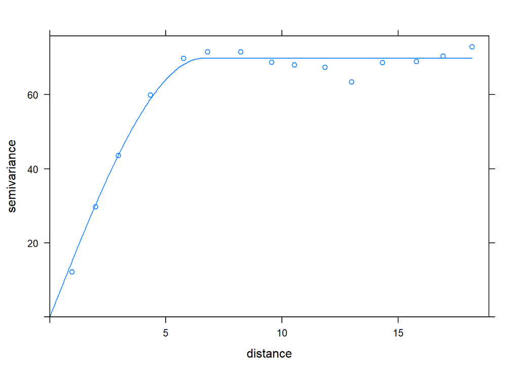

```
## [1] "Coefficient_of_Determination= 0.981974004649492"
```

### 2.15 Plot.Voronoi.LAI.Sum(minx,maxx,miny,maxy,boundary,b,strata,r)

2.15.1功能介绍：

基于分层泰森多边形法绘制复层林林分叶面积指数图

2.15.2参数意义：

minx—样地横坐标最小范围

maxx—样地横坐标最大范围

miny—样地纵坐标最小范围

maxy—样地纵坐标最大范围

boundary—样地边界缓冲区宽度

b—样地中的林木坐标、树种、胸径

strata—不同林层间的分割高度

r—将在林分各林层中没有林木分布的位置添加样点，以避免以林木为中心的泰森多边形过大。r为不同林层添加样点构成泰森多边形外接圆的半径

2.15.3例：

```r
b=Broadleaf.Korean.pine.LAI::b
head(b)
```

```
##           x         y      DBH  H Species
## 1 33.428848 18.981981 65.58075 35      HS
## 2  6.434608 42.039176 66.18077 35      HS
## 3 18.146064 19.266050 52.26441 25      HS
## 4 27.592828 13.896808 32.36649 25      HS
## 5  6.108164 25.639671 35.55580 25      HS
## 6 39.511178  5.185569 53.03717 25      HS
```

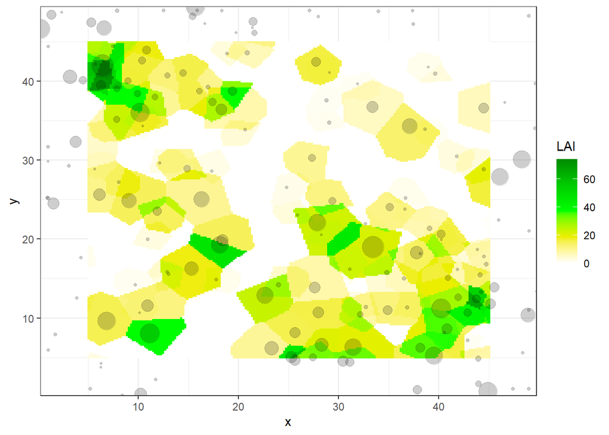

```r
p=Broadleaf.Korean.pine.LAI::Plot.Voronoi.LAI.Sum(minx=0,maxx=50,miny=0,maxy=50,boundary=5,b=b,strata=c(10,16,30),r=c(2,2.5,3.5,4))
p1=p+geom_vline(xintercept = c(5,45),linetype=2)+geom_hline(yintercept =c(5,45),linetype=2)
p1=p+scale_x_continuous(expand= c(0, 5))+scale_y_continuous(expand= c(0, 5))
p2=p1+geom_point(data=b,aes(x=x,y=y),size=b$DBH/8,col="grey4",alpha=0.2)+scale_x_continuous(expand= c(0, 0))+scale_y_continuous(expand= c(0, 0))
p2
```

### 2.16 Single.point.Voronoi.LAI.sum(minx,maxx,miny,maxy,boundary,a,b,strata,r)

2.16.1功能介绍：

基于分层泰森多边形法计算复层林内单一任意位点的叶面积指数

2.16.2参数意义：

minx—样地横坐标最小范围

maxx—样地横坐标最大范围

miny—样地纵坐标最小范围

maxy—样地纵坐标最大范围

boundary—样地边界缓冲区宽度

a—需要计算叶面积指数的位点的坐标

b—样地中的林木坐标、树种、胸径

strata—不同林层间的分割高度

r—将在林分各林层中没有林木分布的位置添加样点，以避免以林木为中心的泰森多边形过大。r为不同林层添加样点构成泰森多边形外接圆的半径

2.16.3例：

```r
set.seed(100)
a=matrix(runif(2,5,45),1,2)
colnames(a)=c("x","y")
a=as.data.frame(a)
a
```

```
##          x       y
## 1 17.31064 15.3069
```

```r
b=Broadleaf.Korean.pine.LAI::b
head(b)
```

```
##           x         y      DBH  H Species
## 1 33.428848 18.981981 65.58075 35      HS
## 2  6.434608 42.039176 66.18077 35      HS
## 3 18.146064 19.266050 52.26441 25      HS
## 4 27.592828 13.896808 32.36649 25      HS
## 5  6.108164 25.639671 35.55580 25      HS
## 6 39.511178  5.185569 53.03717 25      HS
```

```r
result=Broadleaf.Korean.pine.LAI::Single.point.Voronoi.LAI.sum(minx=0,maxx=50,miny=0,maxy=50,boundary=5,a=a,b=b,strata=c(10,16,30),r=c(2,2.5,3.5,4))
result
```

```
##             x       y Species      LAI Species LAI Species      LAI Species LAI
## 1291 17.31064 15.3069      HS 1.776275      LX   0     SMQ 17.00122      LX   0
##        SumLAI Strata_cont
## 1291 18.77749    1.124323
```

### 2.17 mult.point.Voronoi.LAI.sum(minx,maxx,miny,maxy,boundary,a,b,strata,r)

2.17.1功能介绍：

基于分层泰森多边形法计算复层林内多个任意位点的叶面积指数

2.17.2参数意义：

minx—样地横坐标最小范围

maxx—样地横坐标最大范围

miny—样地纵坐标最小范围

maxy—样地纵坐标最大范围

boundary—样地边界缓冲区宽度

a—需要计算叶面积指数的位点的坐标

b—样地中的林木坐标、树种、胸径

strata—不同林层间的分割高度

r—将在林分各林层中没有林木分布的位置添加样点，以避免以林木为中心的泰森多边形过大。r为不同林层添加样点构成泰森多边形外接圆的半径

2.17.3 例：

```r
set.seed(100)
a=matrix(runif(40,5,45),20,2)
colnames(a)=c("x","y")
a=as.data.frame(a)
a
```

```
##            x        y
## 1  17.310644 26.43245
## 2  15.306900 33.43215
## 3  27.092897 26.53395
## 4   7.255326 34.95889
## 5  23.741971 21.80406
## 6  24.350829 11.85681
## 7  37.496105 35.81206
## 8  19.812821 40.27814
## 9  26.862344 26.96387
## 10 11.810482 16.10895
## 11 29.999859 24.53224
## 12 40.286621 42.14020
## 13 16.214154 18.94768
## 14 20.939516 43.16631
## 15 35.502043 32.81097
## 16 31.760868 40.57814
## 17 13.184486 12.21629
## 18 19.300994 30.17563
## 19 19.379005 44.58257
## 20 32.611621 10.21155
```

```r
b=Broadleaf.Korean.pine.LAI::b
head(b)
```

```
##           x         y      DBH  H Species
## 1 33.428848 18.981981 65.58075 35      HS
## 2  6.434608 42.039176 66.18077 35      HS
## 3 18.146064 19.266050 52.26441 25      HS
## 4 27.592828 13.896808 32.36649 25      HS
## 5  6.108164 25.639671 35.55580 25      HS
## 6 39.511178  5.185569 53.03717 25      HS
```

```r
result=Broadleaf.Korean.pine.LAI::mult.point.Voronoi.LAI.sum(minx=0,maxx=50,miny=0,maxy=50,boundary=5,a=a,b=b,strata=c(10,16,30),r=c(2,2.5,3.5,4))
head(result)
```

```
##           x        y Species LAI Species      LAI Species      LAI Species LAI
## 1 17.310644 26.43245      LX   0      LX 0.000000      LS 10.05055      LX   0
## 2 15.306900 33.43215      LX   0      LX 0.000000      LX  0.00000      LX   0
## 3 27.092897 26.53395      LX   0      LX 0.000000      LX  0.00000      LX   0
## 4  7.255326 34.95889      LX   0     SMQ 7.813829      ZD 15.39914      LX   0
## 5 23.741971 21.80406      LX   0      LX 0.000000      LX  0.00000      LX   0
## 6 24.350829 11.85681      LX   0      LX 0.000000      HS 15.18164      LX   0
##     SumLAI Strata_cont
## 1 10.05055    1.200000
## 2  0.00000         NaN
## 3  0.00000         NaN
## 4 23.21297    1.065354
## 5  0.00000         NaN
## 6 15.18164    1.200000
```

### 2.18 Local.single.point.Voronoi.LAI.sum(minx,maxx,miny,maxy,boundary,a,b,strata,r,Lr)

2.18.1功能介绍：

基于分层泰森多边形法计算复层林内单一任意位点的与叶面积指数相关的局部冠层结构特征

2.18.2参数意义：

minx—样地横坐标最小范围

maxx—样地横坐标最大范围

miny—样地纵坐标最小范围

maxy—样地纵坐标最大范围

boundary—样地边界缓冲区宽度

a—需要模拟局部冠层结构参数的位点的坐标

b—样地中的林木坐标、树种、胸径

strata—不同林层间的分割高度

r—将在林分各林层中没有林木分布的位置添加样点，以避免以林木为中心的泰森多边形过大。r为不同林层添加样点构成泰森多边形外接圆的半径

Lr—模拟局部冠层结构参数的圆的半径

2.18.3 例：

```r
set.seed(100)
a=matrix(runif(2,5,45),1,2)
colnames(a)=c("x","y")
a=as.data.frame(a)
a
```

```
##          x       y
## 1 17.31064 15.3069
```

```r
b=Broadleaf.Korean.pine.LAI::b
head(b)
```

```
##           x         y      DBH  H Species
## 1 33.428848 18.981981 65.58075 35      HS
## 2  6.434608 42.039176 66.18077 35      HS
## 3 18.146064 19.266050 52.26441 25      HS
## 4 27.592828 13.896808 32.36649 25      HS
## 5  6.108164 25.639671 35.55580 25      HS
## 6 39.511178  5.185569 53.03717 25      HS
```

```r
result=Broadleaf.Korean.pine.LAI::Local.single.point.Voronoi.LAI.sum(minx=0,maxx=50,miny=0,maxy=50,boundary=5,a=a,b=b,strata=c(10,16,30),r=c(2,2.5,3.5,4),Lr=1.5)
formattable::formattable(result)
```

| x | y | LAI | Local_min_LAI | Local_max_LAI | Local_mean_LAI | Local_sd_LAI | Gap_percent | Canopy_percent | N_L_Percent | B_L_Percent | Strata_cont |
| --- | --- | --- | --- | --- | --- | --- | --- | --- | --- | --- | --- |
| 17.31064 | 15.3069 | 18.77749 | 17.00122 | 35.885 | 18.58303 | 1.961076 | 0 | 1 | 0.09510175 | 0.9048982 | 1.140772 |

### 2.19 Local.mult.point.Voronoi.LAI.sum(minx,maxx,miny,maxy,boundary,a,b,strata,r,Lr)

2.19.1功能介绍：

基于分层泰森多边形法计算复层林内多个任意位点的与叶面积指数相关的局部冠层结构特征

2.19.2参数意义：

minx—样地横坐标最小范围

maxx—样地横坐标最大范围

miny—样地纵坐标最小范围

maxy—样地纵坐标最大范围

boundary—样地边界缓冲区宽度

a—需要模拟局部冠层结构参数的位点的坐标

b—样地中的林木坐标、树种、胸径

strata—不同林层间的分割高度

r—将在林分各林层中没有林木分布的位置添加样点，以避免以林木为中心的泰森多边形过大。r为不同林层添加样点构成泰森多边形外接圆的半径

Lr—模拟局部冠层结构参数的圆的半径

2.19.3 例：

```r
set.seed(100)
a=matrix(runif(40,5,45),20,2)
colnames(a)=c("x","y")
a=as.data.frame(a)
a
```

```
##            x        y
## 1  17.310644 26.43245
## 2  15.306900 33.43215
## 3  27.092897 26.53395
## 4   7.255326 34.95889
## 5  23.741971 21.80406
## 6  24.350829 11.85681
## 7  37.496105 35.81206
## 8  19.812821 40.27814
## 9  26.862344 26.96387
## 10 11.810482 16.10895
## 11 29.999859 24.53224
## 12 40.286621 42.14020
## 13 16.214154 18.94768
## 14 20.939516 43.16631
## 15 35.502043 32.81097
## 16 31.760868 40.57814
## 17 13.184486 12.21629
## 18 19.300994 30.17563
## 19 19.379005 44.58257
## 20 32.611621 10.21155
```

```r
b=Broadleaf.Korean.pine.LAI::b
head(b)
```

```
##           x         y      DBH  H Species
## 1 33.428848 18.981981 65.58075 35      HS
## 2  6.434608 42.039176 66.18077 35      HS
## 3 18.146064 19.266050 52.26441 25      HS
## 4 27.592828 13.896808 32.36649 25      HS
## 5  6.108164 25.639671 35.55580 25      HS
## 6 39.511178  5.185569 53.03717 25      HS
```

```r
result=Broadleaf.Korean.pine.LAI::Local.mult.point.Voronoi.LAI.sum(minx=0,maxx=50,miny=0,maxy=50,boundary=5,a=a,b=b,strata=c(10,16,30),r=c(2,2.5,3.5,4),Lr=1.5)
formattable::formattable(result)
```

| x | y | LAI | Local_min_LAI | Local_max_LAI | Local_mean_LAI | Local_sd_LAI | Gap_percent | Canopy_percent | N_L_Percent | B_L_Percent | Strata_cont |
| --- | --- | --- | --- | --- | --- | --- | --- | --- | --- | --- | --- |
| 17.310644 | 26.43245 | 10.050552 | 2.690695 | 20.828866 | 10.717140 | 2.3361354 | 0.000000000 | 1.0000000 | 9.241609e-01 | 0.07583912 | 1.1525007 |
| 15.306900 | 33.43215 | 0.000000 | 0.000000 | 15.399139 | 3.030910 | 3.7192318 | 0.581818182 | 0.4181818 | 9.260989e-01 | 0.07390106 | 1.2000000 |
| 27.092897 | 26.53395 | 0.000000 | 0.000000 | 34.043668 | 9.373343 | 11.3440750 | 0.385454545 | 0.6145455 | 0.000000e+00 | 1.00000000 | 0.9972436 |
| 7.255326 | 34.95889 | 5.682379 | 5.682379 | 23.212968 | 20.532323 | 4.6246159 | 0.000000000 | 1.0000000 | 6.340156e-02 | 0.93659844 | 1.0566318 |
| 23.741971 | 21.80406 | 0.000000 | 0.000000 | 27.658909 | 1.072384 | 3.7845906 | 0.767272727 | 0.2327273 | 0.000000e+00 | 1.00000000 | 0.7391523 |
| 24.350829 | 11.85681 | 15.181635 | 8.612138 | 19.622435 | 16.849225 | 2.5560426 | 0.000000000 | 1.0000000 | 7.501206e-01 | 0.24987944 | 1.1543800 |
| 37.496105 | 35.81206 | 12.695686 | 12.695686 | 13.553238 | 12.948274 | 0.3916176 | 0.000000000 | 1.0000000 | 1.950747e-02 | 0.98049253 | 1.1843940 |
| 19.812821 | 40.27814 | 13.954960 | 3.951567 | 13.954960 | 12.683716 | 3.3002530 | 0.000000000 | 1.0000000 | 0.000000e+00 | 1.00000000 | 0.8000000 |
| 26.862344 | 26.96387 | 0.000000 | 0.000000 | 34.043668 | 6.586243 | 7.6460068 | 0.360000000 | 0.6400000 | 0.000000e+00 | 1.00000000 | 0.8684171 |
| 11.810482 | 16.10895 | 11.675045 | 0.000000 | 20.190508 | 12.999625 | 7.6496486 | 0.007272727 | 0.9927273 | 3.346229e-01 | 0.66537713 | 1.0287141 |
| 29.999859 | 24.53224 | 34.043668 | 9.039184 | 34.697197 | 32.136611 | 6.6535752 | 0.000000000 | 1.0000000 | 7.394896e-05 | 0.99992605 | 1.0874314 |
| 40.286621 | 42.14020 | 1.892003 | 0.000000 | 2.680474 | 1.425920 | 1.1160329 | 0.360000000 | 0.6400000 | 4.873215e-01 | 0.51267854 | 0.4000000 |
| 16.214154 | 18.94768 | 17.001219 | 0.000000 | 35.885000 | 18.265370 | 16.9718988 | 0.432727273 | 0.5672727 | 9.052287e-01 | 0.09477132 | 1.2000000 |
| 20.939516 | 43.16631 | 3.951567 | 0.000000 | 6.874069 | 5.089785 | 1.9828459 | 0.072727273 | 0.9272727 | 0.000000e+00 | 1.00000000 | 0.6879634 |
| 35.502043 | 32.81097 | 0.000000 | 0.000000 | 12.695686 | 11.495367 | 3.7213533 | 0.094545455 | 0.9054545 | 0.000000e+00 | 1.00000000 | 1.2000000 |
| 31.760868 | 40.57814 | 1.383401 | 0.000000 | 1.383401 | 1.290035 | 0.2927951 | 0.010909091 | 0.9890909 | 2.901316e-02 | 0.97098684 | 0.4000000 |
| 13.184486 | 12.21629 | 10.219530 | 0.000000 | 19.087753 | 9.765787 | 4.3614012 | 0.141818182 | 0.8581818 | 8.960016e-01 | 0.10399835 | 1.1507668 |
| 19.300994 | 30.17563 | 2.690695 | 0.000000 | 2.690695 | 0.880591 | 1.2648235 | 0.672727273 | 0.3272727 | 0.000000e+00 | 1.00000000 | 0.4000000 |
| 19.379005 | 44.58257 | 6.874069 | 3.951567 | 13.363972 | 7.721427 | 2.6537190 | 0.000000000 | 1.0000000 | 0.000000e+00 | 1.00000000 | 0.6737245 |
| 32.611621 | 10.21155 | 28.547222 | 10.529653 | 37.667190 | 23.952812 | 7.9158182 | 0.000000000 | 1.0000000 | 6.777223e-02 | 0.93222777 | 0.9887641 |

### 2.20 Semivariogram.Voronoi.LAI(minx,maxx,miny,maxy,boundary,b,strata,r,seq )

2.20.1功能介绍：

基于分层泰森多边形法模拟复层林的叶面积指数的半变异函数

2.20.2参数意义：

minx—样地横坐标最小范围

maxx—样地横坐标最大范围

miny—样地纵坐标最小范围

maxy—样地纵坐标最大范围

boundary—缓冲区宽度

b—样地中的林木坐标、树种、胸径

r—将在林分中没有林木分布的位置添加样点，以避免以林木为中心的泰森多边形过大。r为添加样点构成泰森多边形外接圆的半径

seq—模拟半变异函数时的空间分辨率

2.20.3例：

```r
b=Broadleaf.Korean.pine.LAI::b
head(b)
```

```
##           x         y      DBH  H Species
## 1 33.428848 18.981981 65.58075 35      HS
## 2  6.434608 42.039176 66.18077 35      HS
## 3 18.146064 19.266050 52.26441 25      HS
## 4 27.592828 13.896808 32.36649 25      HS
## 5  6.108164 25.639671 35.55580 25      HS
## 6 39.511178  5.185569 53.03717 25      HS
```

```r
Broadleaf.Korean.pine.LAI::Semivariogram.Voronoi.LAI(minx=0,maxx=50,miny=0,maxy=50,boundary =5,b=b,strata=c(10,16,30),r=c(2,2.5,3.5,4),seq = 20)
```

```
##   model    psill    range
## 1   Nug 13.27126 0.000000
## 2   Sph 99.49735 6.691065
```

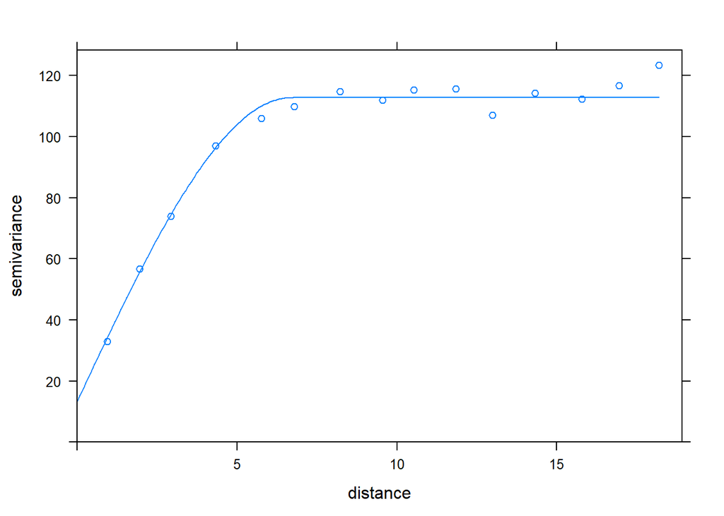

```
## [1] "Coefficient_of_Determination= 0.977115571818784"
```

### 2.21 plot.Local.single.point.Voronoi.LAI(minx,maxx,miny,maxy,a,b,r,Lr)

2.21.1功能介绍：

基于泰森多边形法计算单层林或复层林内单一林层的林地内任意单一位点的与叶面积有关的局部冠层结构参数,并绘图验证。

2.21.2参数意义：

minx—样地横坐标最小范围

maxx—样地横坐标最大范围

miny—样地纵坐标最小范围

maxy—样地纵坐标最大范围

a—需要模拟局部冠层结构参数的位置坐标

b—样地中的林木坐标、树种、胸径

r—将在林分中没有林木分布的位置添加样点，以避免以林木为中心的泰森多边形过大。r为添加样点构成泰森多边形外接圆的半径

Lr—提取局部冠层结构参数时的圆的半径

2.21.3例：

```r
set.seed(100)
a=matrix(runif(2,5,45),1,2)
colnames(a)=c("x","y")
a=as.data.frame(a)
a
```

```
##          x       y
## 1 17.31064 15.3069
```

```r
b=Broadleaf.Korean.pine.LAI::b
b=subset(b,b$H>20 & b$H<30)
b=b[,-4]
head(b)
```

```
##           x         y      DBH Species
## 3 18.146064 19.266050 52.26441      HS
## 4 27.592828 13.896808 32.36649      HS
## 5  6.108164 25.639671 35.55580      HS
## 6 39.511178  5.185569 53.03717      HS
## 7 18.299115 36.464101 31.79671      HS
## 8 25.667076  4.623330 31.56699      HS
```

```
##          x       y      LAI Local_min_LAI Local_max_LAI Local_mean_LAI
## 1 17.31064 15.3069 17.00122      17.00122        35.885       17.20648
##   Local_sd_LAI Gap_percent Canopy_percent N_L_Percent B_L_Percent
## 1     1.961598           0              1  0.02266904    0.977331
```

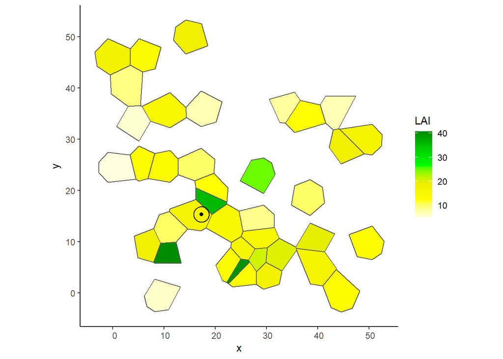

```r
Broadleaf.Korean.pine.LAI::plot.Local.single.point.Voronoi.LAI(minx=0,maxx=50,miny=0,maxy=50,a=a,b=b,r=3.5,Lr=1.5)
```

### 2.22 plot.Local.single.point.Voronoi.LAI.sum(minx,maxx,miny,maxy,a,b,strata,r,Lr)

2.22.1功能介绍：

基于分层泰森多边形法计算复层林内单一任意位点的与叶面积指数相关的局部冠层结构特征，并绘图

2.22.2参数意义：

minx—样地横坐标最小范围

maxx—样地横坐标最大范围

miny—样地纵坐标最小范围

maxy—样地纵坐标最大范围

a—需要模拟局部冠层结构参数的位点的坐标

b—样地中的林木坐标、树种、胸径

strata—不同林层间的分割高度

r—将在林分各林层中没有林木分布的位置添加样点，以避免以林木为中心的泰森多边形过大。r为不同林层添加样点构成泰森多边形外接圆的半径

Lr—模拟局部冠层结构参数的圆的半径

2.22.3 例：

```r
set.seed(100)
a=matrix(runif(2,5,45),1,2)
colnames(a)=c("x","y")
a=as.data.frame(a)
a
```

```
##          x       y
## 1 17.31064 15.3069
```

```r
b=Broadleaf.Korean.pine.LAI::b
head(b)
```

```
##           x         y      DBH  H Species
## 1 33.428848 18.981981 65.58075 35      HS
## 2  6.434608 42.039176 66.18077 35      HS
## 3 18.146064 19.266050 52.26441 25      HS
## 4 27.592828 13.896808 32.36649 25      HS
## 5  6.108164 25.639671 35.55580 25      HS
## 6 39.511178  5.185569 53.03717 25      HS
```

```r
gc()
```

```
##           used (Mb) gc trigger  (Mb) max used  (Mb)
## Ncells 1709832 91.4    2998418 160.2  2998418 160.2
## Vcells 3033143 23.2    8388608  64.0  8388608  64.0
```

```
##          x       y      LAI Local_min_LAI Local_max_LAI Local_mean_LAI
## 1 17.31064 15.3069 18.77749      17.00122        35.885       18.58303
##   Local_sd_LAI Gap_percent Canopy_percent N_L_Percent B_L_Percent Strata_cont
## 1     1.961076           0              1  0.09510175   0.9048982    1.140772
```

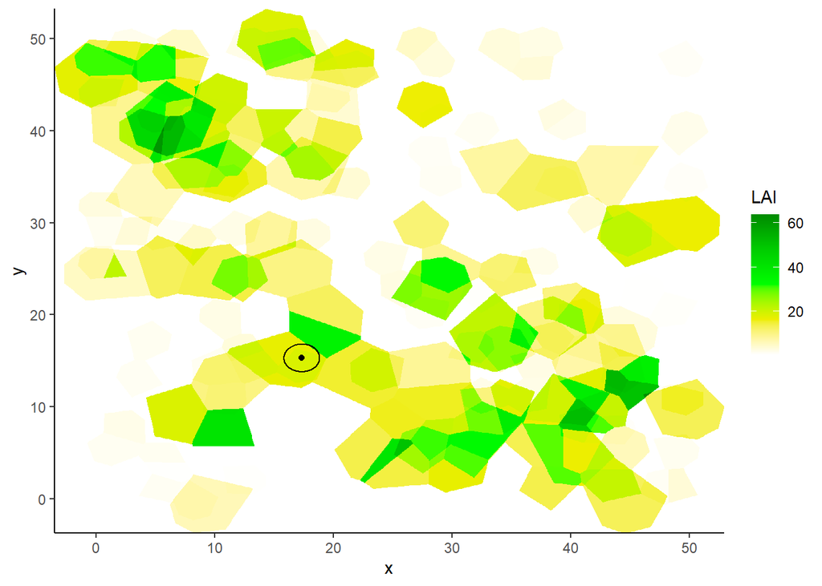

```r
Broadleaf.Korean.pine.LAI::plot.Local.single.point.Voronoi.LAI.sum(minx=0,maxx=50,miny=0,maxy=50,a=a,b=b,strata=c(10,16,30),r=c(2,2.5,3.5,4),Lr=1.5)
```

### 2.23 Voronoi.LAI.sum.ISAA(minx, maxx, miny, maxy, boundary, b, strata, r, indis, lag)

2.23.1功能介绍：

基于分层泰森多边形法进行复层林内叶面积指数的增量空间自相关分析

2.23.2参数意义：

minx—样地横坐标最小范围

maxx—样地横坐标最大范围

miny—样地纵坐标最小范围

maxy—样地纵坐标最大范围

boundary—缓冲区宽度

b—样地中的林木坐标、树种、胸径

strata—不同林层间的分割高度

r—将在林分各林层中没有林木分布的位置添加样点，以避免以林木为中心的泰森多边形过大。r为不同林层添加样点构成泰森多边形外接圆的半径

indis—初始距离

lag—滞后距增量

2.23.3 例：

```r
b=Broadleaf.Korean.pine.LAI::b
head(b)
```

```
##           x         y      DBH  H Species
## 1 33.428848 18.981981 65.58075 35      HS
## 2  6.434608 42.039176 66.18077 35      HS
## 3 18.146064 19.266050 52.26441 25      HS
## 4 27.592828 13.896808 32.36649 25      HS
## 5  6.108164 25.639671 35.55580 25      HS
## 6 39.511178  5.185569 53.03717 25      HS
```

```r
gc()
```

```
##            used  (Mb) gc trigger (Mb) max used  (Mb)
## Ncells  2322732 124.1    4342478  232  3373384 180.2
## Vcells 14021044 107.0   50324907  384 50324907 384.0
```

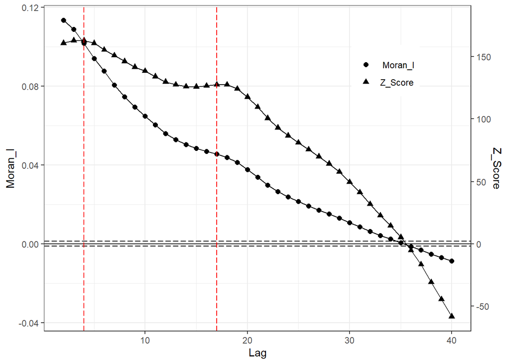

```r
Broadleaf.Korean.pine.LAI::Voronoi.LAI.sum.ISAA(minx=0, maxx=50, miny=0, maxy=50, boundary=5, b=b, strata=c(10,16,30),r=c(2,2.5,3.5,4), indis=1, lag=1)
```

[output not shown]

2.24.1功能介绍：

基于分层泰森多边形反演叶面积的三维空间分布，并以点云绘图

2.24.2参数意义：

minx—样地横坐标最小范围

maxx—样地横坐标最大范围

miny—样地纵坐标最小范围

maxy—样地纵坐标最大范围

boundary—缓冲区宽度

b—样地中的林木坐标、树种、胸径

seq—绘制点云时的空间分辨率

strata—不同林层间的分割高度

r—将在林分各林层中没有林木分布的位置添加样点，以避免以林木为中心的泰森多边形过大。r为不同林层添加样点构成泰森多边形外接圆的半径

S—林分内平均冠形率，冠长与冠幅的比例

theta—绘图水平翻转角度

phi—绘图垂直翻转角度

2.24.3 例：

```r
b=Broadleaf.Korean.pine.LAI::b
head(b)
```

```
##           x         y      DBH  H Species
## 1 33.428848 18.981981 65.58075 35      HS
## 2  6.434608 42.039176 66.18077 35      HS
## 3 18.146064 19.266050 52.26441 25      HS
## 4 27.592828 13.896808 32.36649 25      HS
## 5  6.108164 25.639671 35.55580 25      HS
## 6 39.511178  5.185569 53.03717 25      HS
```

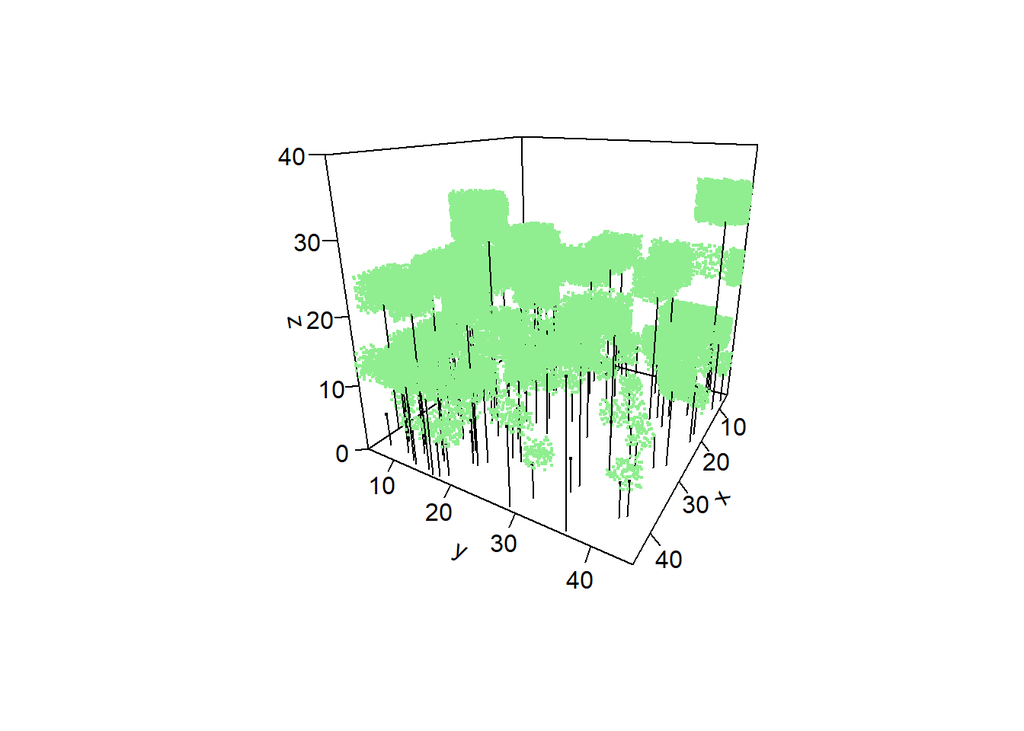

```r
Broadleaf.Korean.pine.LAI::Voronoi.pointcloud(minx=0, maxx=50, miny=0, maxy=50, boundary=5, b=b, seq=100, strata=c(10,16,30),r=c(2,2.5,3.5,4), S=1.5, theta=120, phi=20)
```

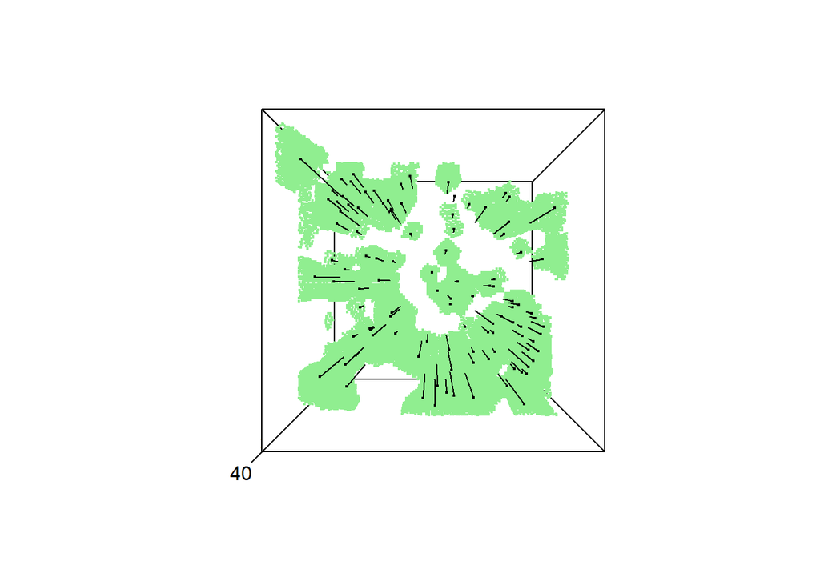

```r
Broadleaf.Korean.pine.LAI::Voronoi.pointcloud(minx=0, maxx=50, miny=0, maxy=50, boundary=5, b=b, seq=100, strata=c(10,16,30),r=c(2,2.5,3.5,4), S=1.5, theta=0, phi=90)
```